# repdata

Anvar K

October 18, 2016

## R Markdown

This is an R Markdown document of Activity Analysis

```r
library(data.table)
file_name<-"activity.csv"
df<-read.csv(file_name, )
df$date<-as.Date(df$date)
```

Histogram of the total number of steps taken each day:

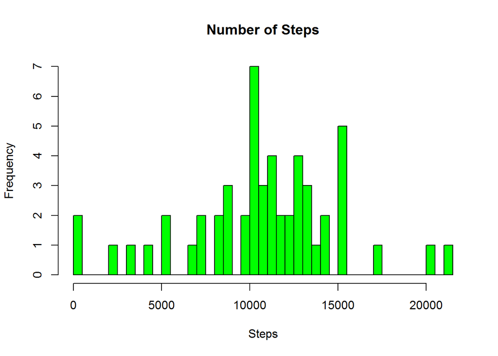

```r
df3 <-  aggregate(.~date, df,FUN=sum)
hist(df3$steps, n = 50, col = "green", xlab = "Steps", main = "Number of Steps")
```

```r
m<-mean(df3$steps, na.rm = TRUE)
med<-median(df3$steps, na.rm = TRUE)
```

Mean value of steps taken per day is: 1.076618910^{4} Median value of steps taken per day is: " 10765

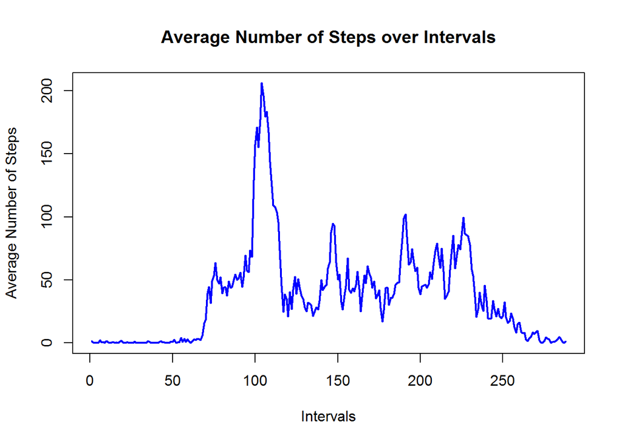

```r
df2 <-  aggregate(.~interval, df,FUN=mean, na.rm=TRUE, na.action=na.pass)
plot(rownames(df2), df2$steps, type = "l", xlab = "Intervals", ylab = "Average Number of Steps", main = "Average Number of Steps over Intervals", col = "blue", lwd = 2)
```

```r
mx_steps<-max(df2$steps, na.rm = TRUE)
mx_interval<- df2$interval[df2$steps == mx_steps]
```

Maximum steps’ interval (averaged over all days) is 835 and the maximum value is 206.1698113

```r
num_of_na<-sum(is.na(df$steps))
```

Number of “NA”s in ‘Steps’ column: 2304

Now replacing “NA” values in Number of Steps by mean values in the same interval and creating a new dataset df4:

```r
df4<-df
for (i in 1:17568) {if (is.na(df[i,1])) {df4[i,1] <- df2$steps[df2$interval == df4[i,3]]}}
df_3 <-  aggregate(.~date, df4,FUN=sum)
df_2 <-  aggregate(.~interval, df4,FUN=mean)
```

Comparison of df and df4 dataframes:

```r
head(df)
```

```
##   steps       date interval
## 1    NA 2012-10-01        0
## 2    NA 2012-10-01        5
## 3    NA 2012-10-01       10
## 4    NA 2012-10-01       15
## 5    NA 2012-10-01       20
## 6    NA 2012-10-01       25
```

```r
head(df4)
```

```
##       steps       date interval
## 1 1.7169811 2012-10-01        0
## 2 0.3396226 2012-10-01        5
## 3 0.1320755 2012-10-01       10
## 4 0.1509434 2012-10-01       15
## 5 0.0754717 2012-10-01       20
## 6 2.0943396 2012-10-01       25
```

```r
##Counting "NA"
num_of_na<-sum(is.na(df4$steps))
```

Number of “NA”s in ‘Steps’ column of the new data set: 0

New data set histogram, median, and mean

```r
num_of_na<-sum(is.na(df$steps))
```

Histogram of the total number of steps taken each day:

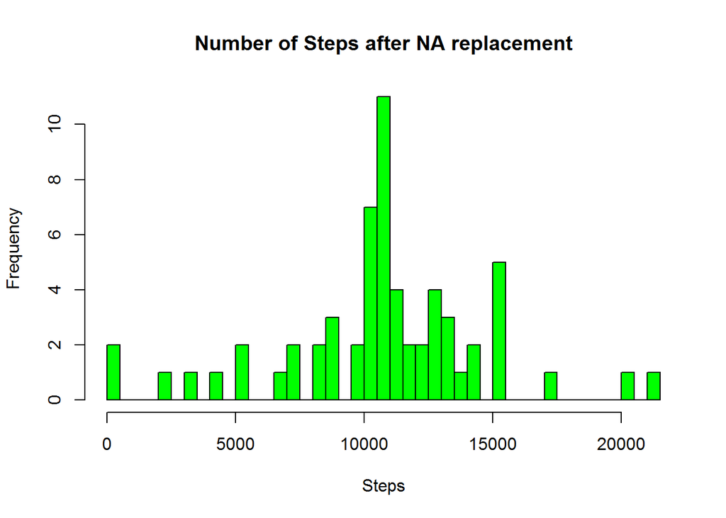

```r
hist(df_3$steps, n = 50, col = "green", xlab = "Steps", main = "Number of Steps after NA replacement")
```

```r
m2<-mean(df_3$steps)
med2<-median(df_3$steps)
```

Mean value of steps taken per day is: 1.076618910^{4}

Median value of steps taken per day is: 1.076618910^{4}

```r
tot<-sum(df$steps, na.rm = TRUE)
tot2<-sum(df4$steps)
s_d<-sd(df2$steps, na.rm = TRUE)
s_d2<-sd(df_2$steps)
s_d3<-sd(df3$steps, na.rm = TRUE)
s_d4<-sd(df_3$steps)
```

Total value of the steps of the initial and the new data sets are: 570608 and 6.567375110^{5} Standard deviations by interval are: 38.6643359 and 38.6643359 Standard deviations by date are: 4269.1804927 and 3974.390746

Thus, there is no change in meadian, mean and standard deviation by interval we replaced them by mean values in the intervals? But there is an increase in total number of steps and some decrease in standard deviation of number of steps by date.

Adding new two-level factor variable week_day to the df4 data set

```r
df4$week_day<-lapply(df4$date, weekdays)

for (i in 1:17568) {if (df4[i,4] == "Saturday" ||df4[i,4] == "Sunday") {df4[i,4] <- "weekend" }
  else {df4[i,4]<- "weekday"}}
head(df4)
```

```
##       steps       date interval week_day
## 1 1.7169811 2012-10-01        0  weekday
## 2 0.3396226 2012-10-01        5  weekday
## 3 0.1320755 2012-10-01       10  weekday
## 4 0.1509434 2012-10-01       15  weekday
## 5 0.0754717 2012-10-01       20  weekday
## 6 2.0943396 2012-10-01       25  weekday
```

Now splitting into two sets: df5 weekend and df6 weekday

```r
df5<-df4[FALSE,]
df6<-df4[FALSE,]
for (i in 1:17568) {if (df4[i,4] == "weekend") {df5[i,] <- df4[i,] }
  else {df6[i,] <- df4[i,] }}

df5<-na.omit(df5)
df6<-na.omit(df6)
```

Averaging over intervals:

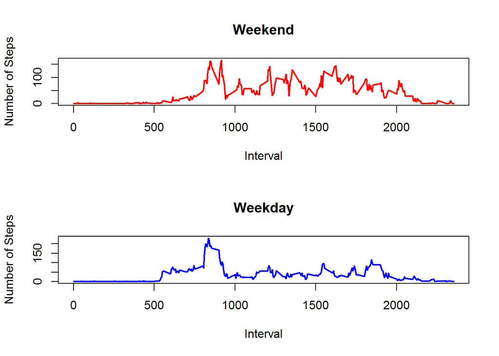

```r
df5<-df5[,-4]
df6<-df6[,-4]

df7 <-  aggregate(.~interval, df5,FUN=mean )
df8 <-  aggregate(.~interval, df6,FUN=mean )

par(mfrow=c(2,1))
plot(df7$interval, df7$steps, type = "l", col = "red", lwd = 2, main = "Weekend", ylab = "Number of Steps", xlab = "Interval")
plot(df8$interval, df8$steps, type = "l", col = "blue", lwd = 2, main = "Weekday",ylab = "Number of Steps", xlab = "Interval")
```